# Disadvantage Factors in Communities_Jennifer Smith

## A Look at Disadvantage Factors by Community Type

### Jennifer Smith

#### August 12, 2022

### Background & Data

The main dataset used in this analysis is from the [Climate and Economic Justice Screening Tool](https://screeningtool.geoplatform.gov/en/#3/33.47/-97.5), which was created by the Biden administration's Executive Order 14008 on Tackling the Climate Crisis at Home and Abroad. The tool was built to identify disadvantaged communities that are "marginalized, underserved, and overburdened by pollution" ("About", 2022).

The tool consolidates information at the census-tract level that includes measurements of many criteria that are used to identify disadvantage. A community (census-tract) is identified as disadvantaged "IF the census tract is above the threshold for one or more environmental or climate indicators AND the census tract is above the threshold for the socioeconomic indicators" ("Methodology", 2022).

The environmental/climate indicators are grouped into eight categories (the IF statement):

1. Climate change (agriculture loss, building loss, or population loss)
2. Clean energy and energy efficiency (high energy burden or PM2.5 in the air)
3. Clean transit (diesel particulate or traffic proximity & volume)
4. Affordable and sustainable housing (lead paint + low home value or high housing burden)
5. Reduction and remediation of legacy pollution (proximity to hazardous waste & materials)
6. Critical clean water and wastewater infrastructure (wastewater discharge)
7. Health burdens (asthma, diabetes, heart disease or low life expectancy)
8. Training and workforce development (low median income, linguistic isolation, high unemployment, poverty level)

The socioecenomic inidicators include (the AND statement):

1. Low income (used with above categories 1-7)
2. High rate of adults without high school degree (used with above category 8)
3. Most adults not enrolled in higher education (used with all above categories)

("Methodology", 2022).

I wanted to investigate how the various criteria for disadvantage are impacting different types communities. The screening tool dataset included population but did not include any kind of information that identified the communities as urban, rural, suburban, etc. To access that information, I used the rural-urban commuting area (RUCA) codes that the Economoic Research Service of the United States Department of Agriculture created to "classify U.S. census tracts using measures of population density, urbanization, and daily commuting" (*2010 Rural-Urban*, 2019). Since both datasets were at the census-tract level, they were simple to combine.

The RUCA codes, however, define ten classifications of communities, which is more granular than I'd planned to analyze. In order to consolidate them into community definitions that are commonly understood, I looked to a paper published by the Washington State Department of Health, which used the RUCA codes combined with population density to define six types of communities: Urban core, Suburban, Large town, Small town, Rural, and Isolated (*Guidelines for Using*, 2016).

These are the community categories used in the analysis.

### Obtaining the Data

All of the data used in our analysis is government data that is publicly available online and can be found in the links below:

- Disadvantaged communities data: https://screeningtool.geoplatform.gov/en/downloads
  - Link called "Communities list data" csv or xlsx
  - Full details of methodology for categories can be found here: https://screeningtool.geoplatform.gov/en/methodology
- Rural-urban commuting area (RUCA) codes: https://www.ers.usda.gov/data-products/rural-urban-commuting-area-codes.aspx
  - Link called "2010 Rural-Urban Commuting Area Codes (revised 7/3/2019)"
- Definitions of community types: https://doh.wa.gov/sites/default/files/legacy/Documents/1500//RUCAGuide.pdf
  - Page 14, Scheme 4

### Visualizations & Findings

To help orient viewers with the communities we'll be analyzing, I wanted to provide an idea of how the U.S. is distributed within them. The main takeaway from this step is that when talking in terms of population, the vast majority live in urban core communities. If talking about land area, however, half is categorized as isolated, with very few residents. These differences can be seen clearly in Figure 1 below.

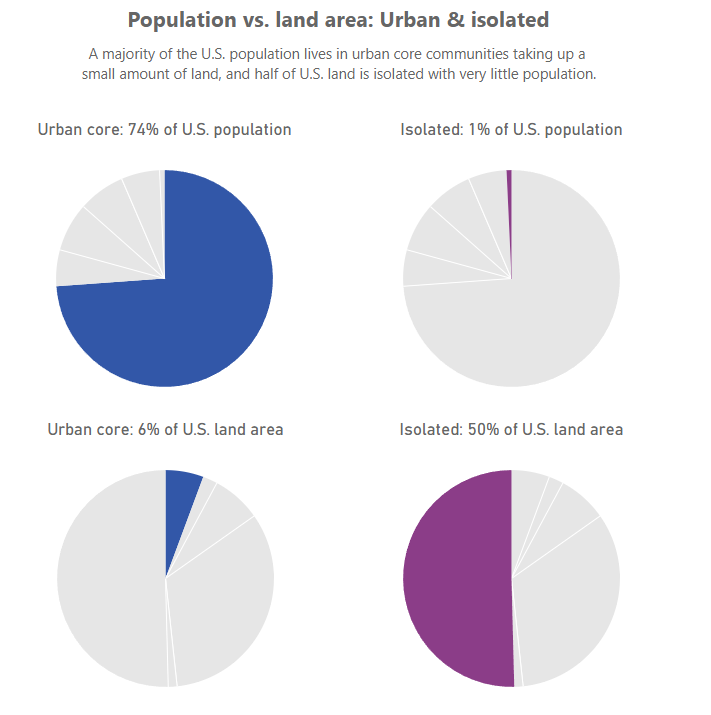

Figure 1. Urban vs. isolated communities in population and land area

Next, I take a deeper look at the population distribution, this time factoring in the portions that are categorized as disadvantaged or not. In Figure 2 below, it is again clear that urban core communities make up a very large majority of the U.S. population, and now one can also see that they make up a large majority of disadvantaged communities as well.

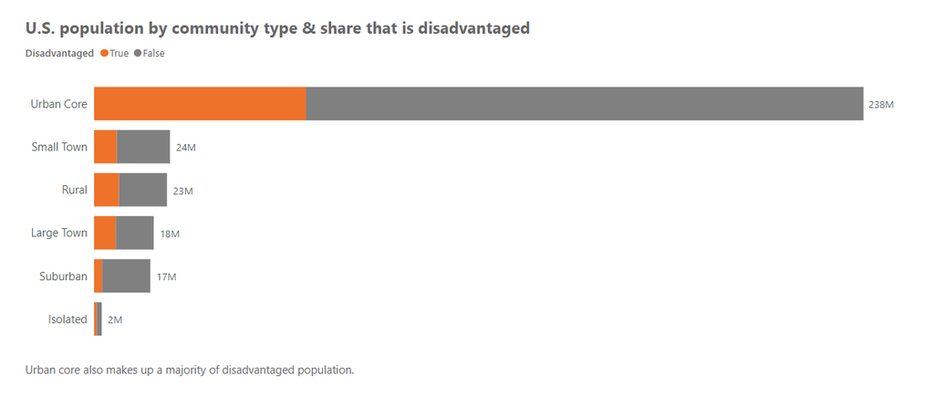

Figure 2. Population by community type and disadvantage

The Figure 2 bar chart does not make it easy to compare the percentage share of each community type group that is disadvantaged, so that questions is explored separately. Figure 3 shows the percent of each group that is disadvantaged. Many of the types are relatively similar in share of disadvantage, with the most notable exception being suburban communities, which have a significantly lower rate of disadvantage than other types of communities. This finding lines up well with preconceived notions and stereotypes of suburban neighborhoods, but is nevertheless interesting to see the scale at which those notions are shown to be true.

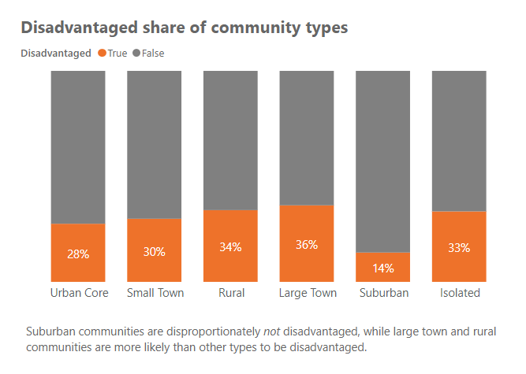

Figure 3. Disadvantage share of community types

As mentioned previously, a community is classified as disadvantaged in this dataset if it meets the definitions of one or more categories of disadvantage, and most categories contain multiple criteria, which do not all need to be met for classification. For example, to qualify in the Health Burdens category, a community must be at or above the 90th percentile for asthma OR heart disease OR diabetes OR low life expectency, not all four.

I wondered how many criteria these disadvantaged communities were exceeding per community on average, and if there was any difference between types of communities. Figure 4 below shows the answer to this question. I found that urban core communities exceeded more criteria on average than any other type of community, which is troubling as urban core also makes up a majority of disadvantaged communities. In contrast, suburban communities exceeded fewer criteria on average, so people living in suburban communities are 1, less likely to be disadvantaged, and 2, even when they are, they are disadvantaged in fewer ways than those in other types.

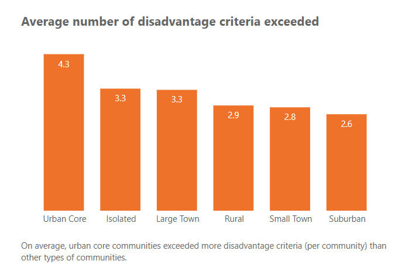

Figure 4. Average number of criteria thresholds exceeded per community

Next, I wanted to look deeper at how the various categories of disadvantage factors are impacting the different types of communities. Figure 5 below shows the count of communities within each type that are impacted by each kind of disadvantage.

The large bar chart on the left shows the urban core counts in the darker orange, with the lighter orange representing all of the other types of communities in those categories. Therefore, the smaller bar charts on the right are what combine to make the lighter orange "All Other Types". This provides sense of scale around how many communities are impacted by these issues.

There are several notable insights from this part of our analysis. First, workforce development in urban core communities is the largest "bucket" of disadvantage. Health burdens are a relatively close second in urban core, and are the top reason in every type of community besides urban core. They all add up to make health burdens broadly the largest factor for disadvantage in the U.S. It is also worth noting that pollution, affordable & sustainable housing, and clean transit availability disproportionately impact the urban core, while climate change is a larger issue for all other types of communities.

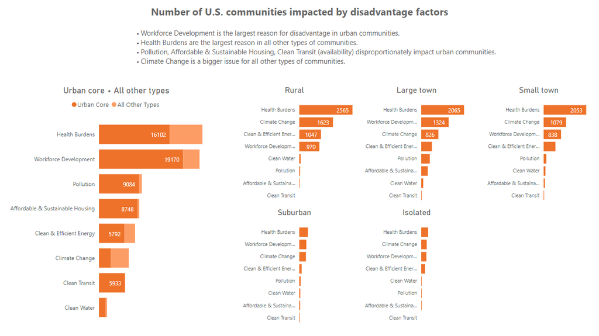

Figure 5. Number of communities impacted by disadvantage factors

Figure 6 below is another view of the same information as Figure 5, but it is helpful to see more simply what the largest buckets of disadvantage are in the U.S. Here we can see that the largest "levers to pull" if we want to improve disadvantage for the most Americans are workforce development and health burdens.

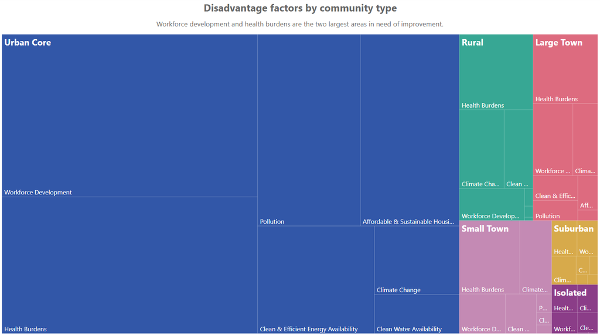

Figure 6. Proportion of disadvantage factors by community type

### References

Climate and Economic Justice Screening Tool. (2022). *Communities list data*. [Data set]. Council on Environmental Quality. **https://screeningtool.geoplatform.gov/en/downloads**

Climate and Economic Justice Screening Tool. (2022). *About*. Council on Environmental Quality. **https://screeningtool.geoplatform.gov/en/about**

Climate and Economic Justice Screening Tool. (2022). *Methodology*. Council on Environmental Quality. **https://screeningtool.geoplatform.gov/en/methodology**

Economic Research Service. (2019). *2010 Rural-Urban Commuting Area Codes (revised 7/3/2019)*. [Data set]. U.S.Department of Agriculture. **https://www.ers.usda.gov/data-products/rural-urban-commuting-area-codes.aspx**

Hailu, A., & Wasserman, C. (2016). *Guidelines for Using Rural-Urban Classification Systems for Community Health Assessment*. Washington State Department of Health. **https://doh.wa.gov/sites/default/files/legacy/Documents/1500//RUCAGuide.pdf**

United States Census Bureau. (2022). *Glossary*. U.S. Census Bureau. **https://www.census.gov/programs-surveys/geography/about/glossary.html#par_textimage_13**

### Appendix: data prep & cleaning

Before uploading to Python I did some data prep & cleaning:

- Used an xlookup to pull the rural/urban codes and data from the RUCA file into the communities data file. Also created new columns for the category names that correspond to the RUCA codes, both specific (i.e. Metropolitan area core) and general (i.e. Metropolitan). The secondary RUCA codes are likely too granular for our analysis, but they're left in for possible future reference.
- Also edited column names to be much shorter and more manageable

```python
import pandas as pd

communities = pd.read_csv('communities-2022-05-31-1915GMT_withRUCA_2.csv')

pd.options.display.max_columns = None

communities.head()
```

|  | Census tract ID | County Name | State/Territory | RUCA Primary | RUCA Scheme 1 | RUCA Scheme 2 | RUCA Scheme 3 | RUCA Scheme 4 | RUCA Secondary | Square Miles, 2010 | Population per Sq Mi, 2010 | Total criteria exceeded | Total categories exceeded | Disadvantaged | Total population | Low inc. not high ed | Ag loss, low inc., not high ed | Expected ag loss rate (perc.) | Expected ag loss rate | Building loss, low inc., not high ed | Expected building loss rate (perc.) | Expected building loss rate | Pop loss, low inc., not high ed | Expected pop loss rate (perc.) | Expected pop loss rate | energy burden, low inc., not high ed | Energy burden (perc.) | Energy burden | PM2.5, low inc., not high ed | … |
| --- | --- | --- | --- | --- | --- | --- | --- | --- | --- | --- | --- | --- | --- | --- | --- | --- | --- | --- | --- | --- | --- | --- | --- | --- | --- | --- | --- | --- | --- | --- |
| 0 | 1001020100 | Autauga County | Alabama | 1.0 | Urban Core | Urban Core | Urban Core | Urban Core | 1.0 | 3.8 | 504.8 | 0 | 0 | False | 1923.0 | False | False | 45.0 | 0.0776 | False | 66.0 | 0.0253 | False | 76.0 | 0.0004 | False | 49.0 | 2.0 | False | … |
| 1 | 1001020200 | Autauga County | Alabama | 1.0 | Urban Core | Urban Core | Urban Core | Urban Core | 1.0 | 1.3 | 1682.5 | 0 | 0 | False | 2028.0 | True | False | 21.0 | 0.0053 | False | 69.0 | 0.0278 | False | 65.0 | 0.0003 | False | 6.0 | 1.0 | False | … |
| 2 | 1001020300 | Autauga County | Alabama | 1.0 | Urban Core | Urban Core | Urban Core | Urban Core | 1.0 | 2.1 | 1633.1 | 0 | 0 | False | 3476.0 | False | False | 39.0 | 0.0527 | False | 54.0 | 0.0163 | False | 59.0 | 0.0002 | False | 68.0 | 3.0 | False | … |
| 3 | 1001020400 | Autauga County | Alabama | 1.0 | Urban Core | Urban Core | Urban Core | Urban Core | 1.0 | 2.5 | 1779.8 | 0 | 0 | False | 3831.0 | False | False | 43.0 | 0.0698 | False | 55.0 | 0.0174 | False | 62.0 | 0.0002 | False | 63.0 | 3.0 | False | … |
| 4 | 1001020500 | Autauga County | Alabama | 1.0 | Urban Core | Urban Core | Urban Core | Urban Core | 1.0 | 4.4 | 2446.4 | 0 | 0 | False | 9883.0 | False | False | 53.0 | 0.1419 | False | 55.0 | 0.0171 | False | 61.0 | 0.0002 | False | 38.0 | 2.0 | False | … |

Identifying non-state territories using missing county names.

```python
pd.options.display.max_rows = None
communities[communities['County Name'].isna() == True ]
```

|  | Census tract ID | County Name | State/Territory | RUCA Primary | RUCA Scheme 1 | RUCA Scheme 2 | RUCA Scheme 3 | RUCA Scheme 4 | RUCA Secondary | Square Miles, 2010 | Population per Sq Mi, 2010 | Total criteria exceeded | Total categories exceeded | Disadvantaged | Total population | Low inc. not high ed | Ag loss, low inc., not high ed | Expected ag loss rate (perc.) | Expected ag loss rate | Building loss, low inc., not high ed | Expected building loss rate (perc.) | Expected building loss rate | Pop loss, low inc., not high ed | Expected pop loss rate (perc.) | Expected pop loss rate | energy burden, low inc., not high ed | Energy burden (perc.) | Energy burden | PM2.5, low inc., not high ed | … |
| --- | --- | --- | --- | --- | --- | --- | --- | --- | --- | --- | --- | --- | --- | --- | --- | --- | --- | --- | --- | --- | --- | --- | --- | --- | --- | --- | --- | --- | --- | --- |
| 73057 | 60010950100 | NaN | American Samoa | NaN | NaN | NaN | NaN | NaN | NaN | NaN | NaN | 1 | 1 | True | NaN | False | False | NaN | NaN | False | NaN | NaN | False | NaN | NaN | False | NaN | NaN | False | … |
| 73058 | 60010950200 | NaN | American Samoa | NaN | NaN | NaN | NaN | NaN | NaN | NaN | NaN | 1 | 1 | True | NaN | False | False | NaN | NaN | False | NaN | NaN | False | NaN | NaN | False | NaN | NaN | False | … |
| 73059 | 60010950300 | NaN | American Samoa | NaN | NaN | NaN | NaN | NaN | NaN | NaN | NaN | 1 | 1 | True | NaN | False | False | NaN | NaN | False | NaN | NaN | False | NaN | NaN | False | NaN | NaN | False | … |
| 73060 | 60010950500 | NaN | American Samoa | NaN | NaN | NaN | NaN | NaN | NaN | NaN | NaN | 2 | 1 | True | NaN | False | False | NaN | NaN | False | NaN | NaN | False | NaN | NaN | False | NaN | NaN | False | … |
| 73061 | 60010950600 | NaN | American Samoa | NaN | NaN | NaN | NaN | NaN | NaN | NaN | NaN | 1 | 1 | True | NaN | False | False | NaN | NaN | False | NaN | NaN | False | NaN | NaN | False | NaN | NaN | False | … |
| 73062 | 60010950700 | NaN | American Samoa | NaN | NaN | NaN | NaN | NaN | NaN | NaN | NaN | 1 | 1 | True | NaN | False | False | NaN | NaN | False | NaN | NaN | False | NaN | NaN | False | NaN | NaN | False | … |
| 73063 | 60010950900 | NaN | American Samoa | NaN | NaN | NaN | NaN | NaN | NaN | NaN | NaN | 1 | 1 | True | NaN | False | False | NaN | NaN | False | NaN | NaN | False | NaN | NaN | False | NaN | NaN | False | … |
| 73064 | 60020951800 | NaN | American Samoa | NaN | NaN | NaN | NaN | NaN | NaN | NaN | NaN | 2 | 1 | True | NaN | False | False | NaN | NaN | False | NaN | NaN | False | NaN | NaN | False | NaN | NaN | False | … |
| 73065 | 60030951900 | NaN | American Samoa | NaN | NaN | NaN | NaN | NaN | NaN | NaN | NaN | 0 | 0 | False | NaN | False | False | NaN | NaN | False | NaN | NaN | False | NaN | NaN | False | NaN | NaN | False | … |
| 73066 | 60040952000 | NaN | American Samoa | NaN | NaN | NaN | NaN | NaN | NaN | NaN | NaN | 0 | 0 | False | NaN | False | False | NaN | NaN | False | NaN | NaN | False | NaN | NaN | False | NaN | NaN | False | … |
| 73067 | 60050951000 | NaN | American Samoa | NaN | NaN | NaN | NaN | NaN | NaN | NaN | NaN | 1 | 1 | True | NaN | False | False | NaN | NaN | False | NaN | NaN | False | NaN | NaN | False | NaN | NaN | False | … |
| 73068 | 60050951100 | NaN | American Samoa | NaN | NaN | NaN | NaN | NaN | NaN | NaN | NaN | 1 | 1 | True | NaN | False | False | NaN | NaN | False | NaN | NaN | False | NaN | NaN | False | NaN | NaN | False | … |
| 73069 | 60050951201 | NaN | American Samoa | NaN | NaN | NaN | NaN | NaN | NaN | NaN | NaN | 1 | 1 | True | NaN | False | False | NaN | NaN | False | NaN | NaN | False | NaN | NaN | False | NaN | NaN | False | … |
| 73070 | 60050951202 | NaN | American Samoa | NaN | NaN | NaN | NaN | NaN | NaN | NaN | NaN | 1 | 1 | True | NaN | False | False | NaN | NaN | False | NaN | NaN | False | NaN | NaN | False | NaN | NaN | False | … |
| 73071 | 60050951203 | NaN | American Samoa | NaN | NaN | NaN | NaN | NaN | NaN | NaN | NaN | 1 | 1 | True | NaN | False | False | NaN | NaN | False | NaN | NaN | False | NaN | NaN | False | NaN | NaN | False | … |
| 73072 | 60050951300 | NaN | American Samoa | NaN | NaN | NaN | NaN | NaN | NaN | NaN | NaN | 1 | 1 | True | NaN | False | False | NaN | NaN | False | NaN | NaN | False | NaN | NaN | False | NaN | NaN | False | … |
| 73073 | 60050951500 | NaN | American Samoa | NaN | NaN | NaN | NaN | NaN | NaN | NaN | NaN | 2 | 1 | True | NaN | False | False | NaN | NaN | False | NaN | NaN | False | NaN | NaN | False | NaN | NaN | False | … |
| 73074 | 60050951600 | NaN | American Samoa | NaN | NaN | NaN | NaN | NaN | NaN | NaN | NaN | 1 | 1 | True | NaN | False | False | NaN | NaN | False | NaN | NaN | False | NaN | NaN | False | NaN | NaN | False | … |
| 73075 | 66010950100 | NaN | Guam | NaN | NaN | NaN | NaN | NaN | NaN | NaN | NaN | 0 | 0 | False | NaN | False | False | NaN | NaN | False | NaN | NaN | False | NaN | NaN | False | NaN | NaN | False | … |
| 73076 | 66010950200 | NaN | Guam | NaN | NaN | NaN | NaN | NaN | NaN | NaN | NaN | 0 | 0 | False | NaN | False | False | NaN | NaN | False | NaN | NaN | False | NaN | NaN | False | NaN | NaN | False | … |
| 73077 | 66010950300 | NaN | Guam | NaN | NaN | NaN | NaN | NaN | NaN | NaN | NaN | 0 | 0 | False | NaN | False | False | NaN | NaN | False | NaN | NaN | False | NaN | NaN | False | NaN | NaN | False | … |
| 73078 | 66010950401 | NaN | Guam | NaN | NaN | NaN | NaN | NaN | NaN | NaN | NaN | 0 | 0 | False | NaN | False | False | NaN | NaN | False | NaN | NaN | False | NaN | NaN | False | NaN | NaN | False | … |
| 73079 | 66010950402 | NaN | Guam | NaN | NaN | NaN | NaN | NaN | NaN | NaN | NaN | 0 | 0 | False | NaN | False | False | NaN | NaN | False | NaN | NaN | False | NaN | NaN | False | NaN | NaN | False | … |
| 73080 | 66010950501 | NaN | Guam | NaN | NaN | NaN | NaN | NaN | NaN | NaN | NaN | 2 | 1 | True | NaN | False | False | NaN | NaN | False | NaN | NaN | False | NaN | NaN | False | NaN | NaN | False | … |
| 73081 | 66010950502 | NaN | Guam | NaN | NaN | NaN | NaN | NaN | NaN | NaN | NaN | 0 | 0 | False | NaN | False | False | NaN | NaN | False | NaN | NaN | False | NaN | NaN | False | NaN | NaN | False | … |
| 73082 | 66010950701 | NaN | Guam | NaN | NaN | NaN | NaN | NaN | NaN | NaN | NaN | 0 | 0 | False | NaN | False | False | NaN | NaN | False | NaN | NaN | False | NaN | NaN | False | NaN | NaN | False | … |
| 73083 | 66010950702 | NaN | Guam | NaN | NaN | NaN | NaN | NaN | NaN | NaN | NaN | 0 | 0 | False | NaN | False | False | NaN | NaN | False | NaN | NaN | False | NaN | NaN | False | NaN | NaN | False | … |
| 73084 | 66010950801 | NaN | Guam | NaN | NaN | NaN | NaN | NaN | NaN | NaN | NaN | 0 | 0 | False | NaN | False | False | NaN | NaN | False | NaN | NaN | False | NaN | NaN | False | NaN | NaN | False | … |
| 73085 | 66010950802 | NaN | Guam | NaN | NaN | NaN | NaN | NaN | NaN | NaN | NaN | 0 | 0 | False | NaN | False | False | NaN | NaN | False | NaN | NaN | False | NaN | NaN | False | NaN | NaN | False | … |
| 73086 | 66010950900 | NaN | Guam | NaN | NaN | NaN | NaN | NaN | NaN | NaN | NaN | 0 | 0 | False | NaN | False | False | NaN | NaN | False | NaN | NaN | False | NaN | NaN | False | NaN | NaN | False | … |

[output cut: 102 more lines]

Dropping all rows containing non-state territories

```python
communities = communities[communities['County Name'].notna()]
```

```python
communities = communities.rename(columns={'State/Territory': 'State'})
communities.tail()
```

|  | Census tract ID | County Name | State | RUCA Primary | RUCA Scheme 1 | RUCA Scheme 2 | RUCA Scheme 3 | RUCA Scheme 4 | RUCA Secondary | Square Miles, 2010 | Population per Sq Mi, 2010 | Total criteria exceeded | Total categories exceeded | Disadvantaged | Total population | Low inc. not high ed | Ag loss, low inc., not high ed | Expected ag loss rate (perc.) | Expected ag loss rate | Building loss, low inc., not high ed | Expected building loss rate (perc.) | Expected building loss rate | Pop loss, low inc., not high ed | Expected pop loss rate (perc.) | Expected pop loss rate | energy burden, low inc., not high ed | Energy burden (perc.) | Energy burden | PM2.5, low inc., not high ed | … |
| --- | --- | --- | --- | --- | --- | --- | --- | --- | --- | --- | --- | --- | --- | --- | --- | --- | --- | --- | --- | --- | --- | --- | --- | --- | --- | --- | --- | --- | --- | --- |
| 74097 | 72153750501 | Yauco Municipio | Puerto Rico | 1.0 | Urban Core | Urban Core | Urban Core | Urban Core | 1.0 | 0.7 | 7153.8 | 3 | 1 | True | 6303.0 | True | False | NaN | NaN | False | NaN | NaN | False | NaN | NaN | False | 80.0 | 4.0 | False | … |
| 74098 | 72153750502 | Yauco Municipio | Puerto Rico | 1.0 | Urban Core | Urban Core | Urban Core | Urban Core | 1.0 | 0.3 | 7938.4 | 3 | 1 | True | 2316.0 | True | False | NaN | NaN | False | NaN | NaN | False | NaN | NaN | False | 61.0 | 3.0 | False | … |
| 74099 | 72153750503 | Yauco Municipio | Puerto Rico | 1.0 | Urban Core | Urban Core | Urban Core | Urban Core | 1.0 | 1.3 | 1840.5 | 3 | 1 | True | 2244.0 | True | False | NaN | NaN | False | NaN | NaN | False | NaN | NaN | False | 81.0 | 4.0 | False | … |
| 74100 | 72153750601 | Yauco Municipio | Puerto Rico | 1.0 | Urban Core | Urban Core | Urban Core | Urban Core | 1.0 | 4.3 | 1250.0 | 3 | 1 | True | 4107.0 | True | False | NaN | NaN | False | NaN | NaN | False | NaN | NaN | False | 81.0 | 4.0 | False | … |
| 74101 | 72153750602 | Yauco Municipio | Puerto Rico | 1.0 | Urban Core | Urban Core | Urban Core | Urban Core | 1.0 | 6.8 | 464.2 | 3 | 2 | True | 2511.0 | True | False | NaN | NaN | False | NaN | NaN | False | NaN | NaN | True | 96.0 | 6.0 | False | … |

Dropping Puerto Rico (missed in previous drop because County Name is not blank). Then confirming 51 states remain (leaving in District of Columbia)

```python
communities = communities[communities['State'] != 'Puerto Rico']
communities['State'].nunique()
```

```
51
```

```python
communities.head()
```

|  | Census tract ID | County Name | State | RUCA Primary | RUCA Scheme 1 | RUCA Scheme 2 | RUCA Scheme 3 | RUCA Scheme 4 | RUCA Secondary | Square Miles, 2010 | Population per Sq Mi, 2010 | Total criteria exceeded | Total categories exceeded | Disadvantaged | Total population | Low inc. not high ed | Ag loss, low inc., not high ed | Expected ag loss rate (perc.) | Expected ag loss rate | Building loss, low inc., not high ed | Expected building loss rate (perc.) | Expected building loss rate | Pop loss, low inc., not high ed | Expected pop loss rate (perc.) | Expected pop loss rate | energy burden, low inc., not high ed | Energy burden (perc.) | Energy burden | PM2.5, low inc., not high ed | … |
| --- | --- | --- | --- | --- | --- | --- | --- | --- | --- | --- | --- | --- | --- | --- | --- | --- | --- | --- | --- | --- | --- | --- | --- | --- | --- | --- | --- | --- | --- | --- |
| 0 | 1001020100 | Autauga County | Alabama | 1.0 | Urban Core | Urban Core | Urban Core | Urban Core | 1.0 | 3.8 | 504.8 | 0 | 0 | False | 1923.0 | False | False | 45.0 | 0.0776 | False | 66.0 | 0.0253 | False | 76.0 | 0.0004 | False | 49.0 | 2.0 | False | … |
| 1 | 1001020200 | Autauga County | Alabama | 1.0 | Urban Core | Urban Core | Urban Core | Urban Core | 1.0 | 1.3 | 1682.5 | 0 | 0 | False | 2028.0 | True | False | 21.0 | 0.0053 | False | 69.0 | 0.0278 | False | 65.0 | 0.0003 | False | 6.0 | 1.0 | False | … |
| 2 | 1001020300 | Autauga County | Alabama | 1.0 | Urban Core | Urban Core | Urban Core | Urban Core | 1.0 | 2.1 | 1633.1 | 0 | 0 | False | 3476.0 | False | False | 39.0 | 0.0527 | False | 54.0 | 0.0163 | False | 59.0 | 0.0002 | False | 68.0 | 3.0 | False | … |
| 3 | 1001020400 | Autauga County | Alabama | 1.0 | Urban Core | Urban Core | Urban Core | Urban Core | 1.0 | 2.5 | 1779.8 | 0 | 0 | False | 3831.0 | False | False | 43.0 | 0.0698 | False | 55.0 | 0.0174 | False | 62.0 | 0.0002 | False | 63.0 | 3.0 | False | … |
| 4 | 1001020500 | Autauga County | Alabama | 1.0 | Urban Core | Urban Core | Urban Core | Urban Core | 1.0 | 4.4 | 2446.4 | 0 | 0 | False | 9883.0 | False | False | 53.0 | 0.1419 | False | 55.0 | 0.0171 | False | 61.0 | 0.0002 | False | 38.0 | 2.0 | False | … |

Dropping columns that only apply to territories

```python
communities = communities.drop(['Unemploy % island (2009), states/PR (2010)',
       ' Below 100% poverty, island (2009), states/PR (2010)',
       'Unemployment, low HS grad, island (2009)',
       'Poverty, low HS grad, island (2009)',
       'Low inc., low HS grad, island (2009)'], axis=1)
communities.head()
```

|  | Census tract ID | County Name | State | RUCA Primary | RUCA Scheme 1 | RUCA Scheme 2 | RUCA Scheme 3 | RUCA Scheme 4 | RUCA Secondary | Square Miles, 2010 | Population per Sq Mi, 2010 | Total criteria exceeded | Total categories exceeded | Disadvantaged | Total population | Low inc. not high ed | Ag loss, low inc., not high ed | Expected ag loss rate (perc.) | Expected ag loss rate | Building loss, low inc., not high ed | Expected building loss rate (perc.) | Expected building loss rate | Pop loss, low inc., not high ed | Expected pop loss rate (perc.) | Expected pop loss rate | energy burden, low inc., not high ed | Energy burden (perc.) | Energy burden | PM2.5, low inc., not high ed | … |
| --- | --- | --- | --- | --- | --- | --- | --- | --- | --- | --- | --- | --- | --- | --- | --- | --- | --- | --- | --- | --- | --- | --- | --- | --- | --- | --- | --- | --- | --- | --- |
| 0 | 1001020100 | Autauga County | Alabama | 1.0 | Urban Core | Urban Core | Urban Core | Urban Core | 1.0 | 3.8 | 504.8 | 0 | 0 | False | 1923.0 | False | False | 45.0 | 0.0776 | False | 66.0 | 0.0253 | False | 76.0 | 0.0004 | False | 49.0 | 2.0 | False | … |
| 1 | 1001020200 | Autauga County | Alabama | 1.0 | Urban Core | Urban Core | Urban Core | Urban Core | 1.0 | 1.3 | 1682.5 | 0 | 0 | False | 2028.0 | True | False | 21.0 | 0.0053 | False | 69.0 | 0.0278 | False | 65.0 | 0.0003 | False | 6.0 | 1.0 | False | … |
| 2 | 1001020300 | Autauga County | Alabama | 1.0 | Urban Core | Urban Core | Urban Core | Urban Core | 1.0 | 2.1 | 1633.1 | 0 | 0 | False | 3476.0 | False | False | 39.0 | 0.0527 | False | 54.0 | 0.0163 | False | 59.0 | 0.0002 | False | 68.0 | 3.0 | False | … |
| 3 | 1001020400 | Autauga County | Alabama | 1.0 | Urban Core | Urban Core | Urban Core | Urban Core | 1.0 | 2.5 | 1779.8 | 0 | 0 | False | 3831.0 | False | False | 43.0 | 0.0698 | False | 55.0 | 0.0174 | False | 62.0 | 0.0002 | False | 63.0 | 3.0 | False | … |
| 4 | 1001020500 | Autauga County | Alabama | 1.0 | Urban Core | Urban Core | Urban Core | Urban Core | 1.0 | 4.4 | 2446.4 | 0 | 0 | False | 9883.0 | False | False | 53.0 | 0.1419 | False | 55.0 | 0.0171 | False | 61.0 | 0.0002 | False | 38.0 | 2.0 | False | … |

Viewing value counts of columns. I don't feel we should delete any further rows with missing values.

```python
communities.count()
```

```
Census tract ID                               73057
County Name                                   73057
State                                         73057
RUCA Primary                                  73057
RUCA Scheme 1                                 73057
RUCA Scheme 2                                 73057
RUCA Scheme 3                                 73057
RUCA Scheme 4                                 73057
RUCA Secondary                                73057
Square Miles, 2010                            73057
Population per Sq Mi, 2010                    73057
Total criteria exceeded                       73057
Total categories exceeded                     73057
Disadvantaged                                 73057
Total population                              73031
Low inc. not high ed                          73057
Ag loss, low inc., not high ed                73057
Expected ag loss rate (perc.)                 72738
Expected ag loss rate                         72738
Building loss, low inc., not high ed          73057
Expected building loss rate (perc.)           72687
Expected building loss rate                   72687
Pop loss, low inc., not high ed               73057
Expected pop loss rate (perc.)                72530
Expected pop loss rate                        72530
energy burden, low inc., not high ed          73057
Energy burden (perc.)                         72194
Energy burden                                 72194
PM2.5, low inc., not high ed                  73057
PM2.5 in the air (perc.)                      72259
PM2.5 in the air                              72259
diesel part, low inc., not high ed            73057
Diesel part exposure (perc.)                  72501
Diesel part exposure                          72501
Traffic, low inc., not high ed                73057
Traffic proximity (perc.)                     70406
Traffic proximity                             70406
Housing burden, low inc., not high ed         73057
Housing burden (percent) (perc.)              72092
Housing burden (percent)                      72092
```

[output cut: 32 more lines]

```
Linguistic, low HS grad, not high ed          73057
Linguistic isolation (percent) (perc.)        72202
Linguistic isolation (percent)                72202
Unemployment, low HS grad, not high ed        73057
Unemployment (percent) (perc.)                72275
Unemployment (percent)                        72275
Poverty, low HS grad, not high ed             73057
Percent below 200% Poverty Ln (perc.)         72238
Percent below 200% Poverty Ln                 72238
Percent below 100% Poverty Ln (perc.)         72238
Percent below 100% Poverty Ln                 72238
Percent > age 25 no HS degree (perc.)         72367
Percent > age 25 no HS degree                 72367
Not enrolled in higher ed %                   72385
dtype: int64
```

Looking at datatypes, confirming that all True/False columns are indeed categorized as bool.

```python
communities.dtypes
```

```
Census tract ID                                 int64
County Name                                    object
State                                          object
RUCA Primary                                  float64
RUCA Scheme 1                                  object
RUCA Scheme 2                                  object
RUCA Scheme 3                                  object
RUCA Scheme 4                                  object
RUCA Secondary                                float64
Square Miles, 2010                            float64
Population per Sq Mi, 2010                    float64
Total criteria exceeded                         int64
Total categories exceeded                       int64
Disadvantaged                                    bool
Total population                              float64
Low inc. not high ed                             bool
Ag loss, low inc., not high ed                   bool
Expected ag loss rate (perc.)                 float64
Expected ag loss rate                         float64
Building loss, low inc., not high ed             bool
Expected building loss rate (perc.)           float64
Expected building loss rate                   float64
Pop loss, low inc., not high ed                  bool
Expected pop loss rate (perc.)                float64
Expected pop loss rate                        float64
energy burden, low inc., not high ed             bool
Energy burden (perc.)                         float64
Energy burden                                 float64
PM2.5, low inc., not high ed                     bool
PM2.5 in the air (perc.)                      float64
PM2.5 in the air                              float64
diesel part, low inc., not high ed               bool
Diesel part exposure (perc.)                  float64
Diesel part exposure                          float64
Traffic, low inc., not high ed                   bool
Traffic proximity (perc.)                     float64
Traffic proximity                             float64
Housing burden, low inc., not high ed            bool
Housing burden (percent) (perc.)              float64
Housing burden (percent)                      float64
```

[output cut: 32 more lines]

```
Linguistic, low HS grad, not high ed             bool
Linguistic isolation (percent) (perc.)        float64
Linguistic isolation (percent)                float64
Unemployment, low HS grad, not high ed           bool
Unemployment (percent) (perc.)                float64
Unemployment (percent)                        float64
Poverty, low HS grad, not high ed                bool
Percent below 200% Poverty Ln (perc.)         float64
Percent below 200% Poverty Ln                 float64
Percent below 100% Poverty Ln (perc.)         float64
Percent below 100% Poverty Ln                 float64
Percent > age 25 no HS degree (perc.)         float64
Percent > age 25 no HS degree                 float64
Not enrolled in higher ed %                   float64
dtype: object
```

Remembered we wanted to potentially look at the factors as more general categories. In the below few cells, a new csv file was imported to code the factors into categories, and then used to create new column names for the communities dataframe so the factor category is encoded into the column names so we can reference them for counts/aggregations etc.

```python
col_names = pd.read_csv('factor broad categories_2.csv')
col_names.head()
```

|  | Factor Category | UPDATED CODE | UPDATED COL NAMES | New Name | Original Column Name |
| --- | --- | --- | --- | --- | --- |
| 0 | General | 0 | Percent below 200% Poverty Ln (perc.)_0 | Percent below 200% Poverty Ln (perc.) | Percent of individuals below 200% Federal Pove... |
| 1 | General | 0 | Percent below 200% Poverty Ln_0 | Percent below 200% Poverty Ln | Percent of individuals below 200% Federal Pove... |
| 2 | General | 0 | Not enrolled in higher ed %_0 | Not enrolled in higher ed % | Percent of residents who are not currently enr... |
| 3 | Climate change | 1 | Ag loss, low inc., not high ed_1 | Ag loss, low inc., not high ed | Greater than or equal to the 90th percentile f... |
| 4 | Climate change | 1 | Expected ag loss rate (perc.)_1 | Expected ag loss rate (perc.) | Expected agricultural loss rate (Natural Hazar... |

```python
new_col_dict = dict(zip(col_names['New Name'], col_names['UPDATED COL NAMES']))
communities.rename(columns=new_col_dict, inplace=True)
communities.head()
```

|  | Census tract ID | County Name | State | RUCA Primary | RUCA Scheme 1 | RUCA Scheme 2 | RUCA Scheme 3 | RUCA Scheme 4 | RUCA Secondary | Square Miles, 2010 | Population per Sq Mi, 2010 | Total criteria exceeded | Total categories exceeded | Disadvantaged | Total population | Low inc. not high ed | Ag loss, low inc., not high ed_1 | Expected ag loss rate (perc.)_1 | Expected ag loss rate_1 | Building loss, low inc., not high ed_1 | Expected building loss rate (perc.)_1 | Expected building loss rate_1 | Pop loss, low inc., not high ed_1 | Expected pop loss rate (perc.)_1 | Expected pop loss rate_1 | energy burden, low inc., not high ed_2 | Energy burden (perc.)_2 | Energy burden_2 | PM2.5, low inc., not high ed_2 | … |
| --- | --- | --- | --- | --- | --- | --- | --- | --- | --- | --- | --- | --- | --- | --- | --- | --- | --- | --- | --- | --- | --- | --- | --- | --- | --- | --- | --- | --- | --- | --- |
| 0 | 1001020100 | Autauga County | Alabama | 1.0 | Urban Core | Urban Core | Urban Core | Urban Core | 1.0 | 3.8 | 504.8 | 0 | 0 | False | 1923.0 | False | False | 45.0 | 0.0776 | False | 66.0 | 0.0253 | False | 76.0 | 0.0004 | False | 49.0 | 2.0 | False | … |
| 1 | 1001020200 | Autauga County | Alabama | 1.0 | Urban Core | Urban Core | Urban Core | Urban Core | 1.0 | 1.3 | 1682.5 | 0 | 0 | False | 2028.0 | True | False | 21.0 | 0.0053 | False | 69.0 | 0.0278 | False | 65.0 | 0.0003 | False | 6.0 | 1.0 | False | … |
| 2 | 1001020300 | Autauga County | Alabama | 1.0 | Urban Core | Urban Core | Urban Core | Urban Core | 1.0 | 2.1 | 1633.1 | 0 | 0 | False | 3476.0 | False | False | 39.0 | 0.0527 | False | 54.0 | 0.0163 | False | 59.0 | 0.0002 | False | 68.0 | 3.0 | False | … |
| 3 | 1001020400 | Autauga County | Alabama | 1.0 | Urban Core | Urban Core | Urban Core | Urban Core | 1.0 | 2.5 | 1779.8 | 0 | 0 | False | 3831.0 | False | False | 43.0 | 0.0698 | False | 55.0 | 0.0174 | False | 62.0 | 0.0002 | False | 63.0 | 3.0 | False | … |
| 4 | 1001020500 | Autauga County | Alabama | 1.0 | Urban Core | Urban Core | Urban Core | Urban Core | 1.0 | 4.4 | 2446.4 | 0 | 0 | False | 9883.0 | False | False | 53.0 | 0.1419 | False | 55.0 | 0.0171 | False | 61.0 | 0.0002 | False | 38.0 | 2.0 | False | … |

```python
communities.columns
```

```
Index(['Census tract ID', 'County Name', 'State', 'RUCA Primary',
       'RUCA Scheme 1', 'RUCA Scheme 2', 'RUCA Scheme 3', 'RUCA Scheme 4',
       'RUCA Secondary', 'Square Miles, 2010', 'Population per Sq Mi, 2010',
       'Total criteria exceeded', 'Total categories exceeded', 'Disadvantaged',
       'Total population', 'Low inc. not high ed',
       'Ag loss, low inc., not high ed_1', 'Expected ag loss rate (perc.)_1',
       'Expected ag loss rate_1', 'Building loss, low inc., not high ed_1',
       'Expected building loss rate (perc.)_1',
       'Expected building loss rate_1', 'Pop loss, low inc., not high ed_1',
       'Expected pop loss rate (perc.)_1', 'Expected pop loss rate_1',
       'energy burden, low inc., not high ed_2', 'Energy burden (perc.)_2',
       'Energy burden_2', 'PM2.5, low inc., not high ed_2',
       'PM2.5 in the air (perc.)_2', 'PM2.5 in the air_2',
       'diesel part, low inc., not high ed_3',
       'Diesel part exposure (perc.)_3', 'Diesel part exposure_3',
       'Traffic, low inc., not high ed_3', 'Traffic proximity (perc.)_3',
       'Traffic proximity_3', 'Housing burden, low inc., not high ed_4',
       'Housing burden (percent) (perc.)_4', 'Housing burden (percent)_4',
       'Lead, low house val, low inc., not high ed_4',
       'Percent pre-1960s housing (perc.)_4', 'Percent pre-1960s housing_4',
       'Median housing value (perc.)_4', 'Median housing value_4',
       'Haz waste, low inc., not high ed_5',
       'Hazardous waste proximity (perc.)_5', 'Hazardous waste proximity_5',
       'Superfund, low inc., not high ed_5', 'Superfund Proximity (perc.)_5',
       'Superfund Proximity_5', 'RMP, low inc., not high ed_5',
       'RMP Proximity (perc.)_5', 'RMP Proximity_5',
       'Wastewater, low inc., not high ed_6', 'Wastewater discharge (perc.)_6',
       'Wastewater discharge_6', 'Asthma, low inc., not high ed_7',
       'Asthma in adults (perc.)_7', 'Asthma in adults_7',
       'Diabetes, low inc., not high ed_7', 'Diabetes in adults (perc.)_7',
       'Diabetes in adults_7', 'Heart disease, low inc., not high ed_7',
       'Heart disease in adults (perc.)_7', 'Heart disease in adults_7',
       'Low life exp., low inc., not high ed_7',
       'Low life expectancy (perc.)_7', 'Life expectancy (years)_7',
       'Low inc., low HS grad, not high ed_8',
       'Median hh inc. (% of area median) (perc.)_8',
       'Median hh inc. (% of area median)_8',
       'Linguistic, low HS grad, not high ed_8',
       'Linguistic isolation (percent) (perc.)_8',
       'Linguistic isolation (percent)_8',
       'Unemployment, low HS grad, not high ed_8',
       'Unemployment (percent) (perc.)_8', 'Unemployment (percent)_8',
       'Poverty, low HS grad, not high ed_8',
       'Percent below 200% Poverty Ln (perc.)_0',
       'Percent below 200% Poverty Ln_0',
       'Percent below 100% Poverty Ln (perc.)_8',
       'Percent below 100% Poverty Ln_8',
       'Percent > age 25 no HS degree (perc.)_8',
       'Percent > age 25 no HS degree_8', 'Not enrolled in higher ed %_0'],
      dtype='object')
```

Creating new dataframe that deletes everything except bool columns, to be used in aggregating the factors so they can be counted.

```python
communities_bool = communities.drop(columns = ['Expected ag loss rate (perc.)_1',
       'Expected ag loss rate_1',
       'Expected building loss rate (perc.)_1',
       'Expected building loss rate_1',
       'Expected pop loss rate (perc.)_1', 'Expected pop loss rate_1', 'Energy burden (perc.)_2',
       'Energy burden_2',
       'PM2.5 in the air (perc.)_2', 'PM2.5 in the air_2',
       'Diesel part exposure (perc.)_3', 'Diesel part exposure_3','Traffic proximity (perc.)_3',
       'Traffic proximity_3',
       'Housing burden (percent) (perc.)_4', 'Housing burden (percent)_4',
       'Percent pre-1960s housing (perc.)_4', 'Percent pre-1960s housing_4',
       'Median housing value (perc.)_4', 'Median housing value_4',
       'Hazardous waste proximity (perc.)_5', 'Hazardous waste proximity_5', 'Superfund Proximity (perc.)_5',
       'Superfund Proximity_5',
       'RMP Proximity (perc.)_5', 'RMP Proximity_5', 'Wastewater discharge (perc.)_6',
       'Wastewater discharge_6',
       'Asthma in adults (perc.)_7', 'Asthma in adults_7', 'Diabetes in adults (perc.)_7',
       'Diabetes in adults_7',
       'Heart disease in adults (perc.)_7', 'Heart disease in adults_7',
       'Low life expectancy (perc.)_7', 'Life expectancy (years)_7',
       'Median hh inc. (% of area median) (perc.)_8',
       'Median hh inc. (% of area median)_8',
       'Linguistic isolation (percent) (perc.)_8',
       'Linguistic isolation (percent)_8',
       'Unemployment (percent) (perc.)_8', 'Unemployment (percent)_8',
       'Percent below 200% Poverty Ln (perc.)_0',
       'Percent below 200% Poverty Ln_0',
       'Percent below 100% Poverty Ln (perc.)_8',
       'Percent below 100% Poverty Ln_8',
       'Percent > age 25 no HS degree (perc.)_8',
       'Percent > age 25 no HS degree_8', 'Not enrolled in higher ed %_0'])
communities_bool.head()
```

|  | Census tract ID | County Name | State | RUCA Primary | RUCA Scheme 1 | RUCA Scheme 2 | RUCA Scheme 3 | RUCA Scheme 4 | RUCA Secondary | Square Miles, 2010 | Population per Sq Mi, 2010 | Total criteria exceeded | Total categories exceeded | Disadvantaged | Total population | Low inc. not high ed | Ag loss, low inc., not high ed_1 | Building loss, low inc., not high ed_1 | Pop loss, low inc., not high ed_1 | energy burden, low inc., not high ed_2 | PM2.5, low inc., not high ed_2 | diesel part, low inc., not high ed_3 | Traffic, low inc., not high ed_3 | Housing burden, low inc., not high ed_4 | Lead, low house val, low inc., not high ed_4 | Haz waste, low inc., not high ed_5 | Superfund, low inc., not high ed_5 | RMP, low inc., not high ed_5 | Wastewater, low inc., not high ed_6 | … |
| --- | --- | --- | --- | --- | --- | --- | --- | --- | --- | --- | --- | --- | --- | --- | --- | --- | --- | --- | --- | --- | --- | --- | --- | --- | --- | --- | --- | --- | --- | --- |
| 0 | 1001020100 | Autauga County | Alabama | 1.0 | Urban Core | Urban Core | Urban Core | Urban Core | 1.0 | 3.8 | 504.8 | 0 | 0 | False | 1923.0 | False | False | False | False | False | False | False | False | False | False | False | False | False | False | … |
| 1 | 1001020200 | Autauga County | Alabama | 1.0 | Urban Core | Urban Core | Urban Core | Urban Core | 1.0 | 1.3 | 1682.5 | 0 | 0 | False | 2028.0 | True | False | False | False | False | False | False | False | False | False | False | False | False | False | … |
| 2 | 1001020300 | Autauga County | Alabama | 1.0 | Urban Core | Urban Core | Urban Core | Urban Core | 1.0 | 2.1 | 1633.1 | 0 | 0 | False | 3476.0 | False | False | False | False | False | False | False | False | False | False | False | False | False | False | … |
| 3 | 1001020400 | Autauga County | Alabama | 1.0 | Urban Core | Urban Core | Urban Core | Urban Core | 1.0 | 2.5 | 1779.8 | 0 | 0 | False | 3831.0 | False | False | False | False | False | False | False | False | False | False | False | False | False | False | … |
| 4 | 1001020500 | Autauga County | Alabama | 1.0 | Urban Core | Urban Core | Urban Core | Urban Core | 1.0 | 4.4 | 2446.4 | 0 | 0 | False | 9883.0 | False | False | False | False | False | False | False | False | False | False | False | False | False | False | … |